# Проведение A/B тестирования

**Проверка гипотезы с целью повышения ключевых метрик**

На основании перечня гипотез от маркетингового отдела по повышению ключевых метрик необходимо выбрать наиболее приоритетную, а также провести сравнительный анализ и принять решение о внедрении изменений или отказе от работы с гипотезой.

**План работы**

1. Выбор наиболее приоритетной гипотезы
2. Проведение тестирования
3. Подготовка данных для анализа
4. Анализ ключевых метрик
5. Проверка на наличие аномалий
6. Оценка статистической значимости
7. Принятие решения о дальнейшей работе с гипотезой

```python
import pandas as pd
import numpy as np
import scipy.stats as stats
import matplotlib.pyplot as plt
import datetime as dt
```

```python
pd.set_option('display.max_colwidth', 400)
```

## Приоритизация гипотез для A/B тестирования

Для выбора гипотезы для исследования необходимо провести оценку их приоритетности и потенциальной эффективности.

### Обзор данных

```python
try:
    hypothesis = pd.read_csv('Datasets/hypothesis.csv')
except:
    hypothesis = pd.read_csv('https://code.s3.yandex.net/datasets/hypothesis.csv')
```

```python
hypothesis
```

|  | Hypothesis | Reach | Impact | Confidence | Efforts |
| --- | --- | --- | --- | --- | --- |
| 0 | Добавить два новых канала привлечения трафика, что позволит привлекать на 30% больше пользователей | 3 | 10 | 8 | 6 |
| 1 | Запустить собственную службу доставки, что сократит срок доставки заказов | 2 | 5 | 4 | 10 |
| 2 | Добавить блоки рекомендаций товаров на сайт интернет магазина, чтобы повысить конверсию и средний чек заказа | 8 | 3 | 7 | 3 |
| 3 | Изменить структура категорий, что увеличит конверсию, т.к. пользователи быстрее найдут нужный товар | 8 | 3 | 3 | 8 |
| 4 | Изменить цвет фона главной страницы, чтобы увеличить вовлеченность пользователей | 3 | 1 | 1 | 1 |
| 5 | Добавить страницу отзывов клиентов о магазине, что позволит увеличить количество заказов | 3 | 2 | 2 | 3 |
| 6 | Показать на главной странице баннеры с актуальными акциями и распродажами, чтобы увеличить конверсию | 5 | 3 | 8 | 3 |
| 7 | Добавить форму подписки на все основные страницы, чтобы собрать базу клиентов для email-рассылок | 10 | 7 | 8 | 5 |
| 8 | Запустить акцию, дающую скидку на товар в день рождения | 1 | 9 | 9 | 5 |

Данные заполнены корректно  
Наименования гипотез, а также показатели `Reach`, `Impact`, `Confidence` и `Efforts` не содержат пропусков и приведены к верному формату.

### Расчет ICE score

Выбор наиболее приоритетной гипотезы по методу ICE:

ICE score = (Impact x Confidence) / Efforts

```python
hypothesis['ICE_score'] = round(hypothesis['Impact'] * hypothesis['Confidence'] / hypothesis['Efforts'], 1)
hypothesis = hypothesis.sort_values(by='ICE_score', ascending = False).reset_index(drop=True)
```

```python
hypothesis
```

|  | Hypothesis | Reach | Impact | Confidence | Efforts | ICE_score |
| --- | --- | --- | --- | --- | --- | --- |
| 0 | Запустить акцию, дающую скидку на товар в день рождения | 1 | 9 | 9 | 5 | 16.2 |
| 1 | Добавить два новых канала привлечения трафика, что позволит привлекать на 30% больше пользователей | 3 | 10 | 8 | 6 | 13.3 |
| 2 | Добавить форму подписки на все основные страницы, чтобы собрать базу клиентов для email-рассылок | 10 | 7 | 8 | 5 | 11.2 |
| 3 | Показать на главной странице баннеры с актуальными акциями и распродажами, чтобы увеличить конверсию | 5 | 3 | 8 | 3 | 8.0 |
| 4 | Добавить блоки рекомендаций товаров на сайт интернет магазина, чтобы повысить конверсию и средний чек заказа | 8 | 3 | 7 | 3 | 7.0 |
| 5 | Запустить собственную службу доставки, что сократит срок доставки заказов | 2 | 5 | 4 | 10 | 2.0 |
| 6 | Добавить страницу отзывов клиентов о магазине, что позволит увеличить количество заказов | 3 | 2 | 2 | 3 | 1.3 |
| 7 | Изменить структура категорий, что увеличит конверсию, т.к. пользователи быстрее найдут нужный товар | 8 | 3 | 3 | 8 | 1.1 |
| 8 | Изменить цвет фона главной страницы, чтобы увеличить вовлеченность пользователей | 3 | 1 | 1 | 1 | 1.0 |

```python
print(f'''Наиболее приоритетной по методу ICE является гипотеза:
`{hypothesis["Hypothesis"][0]}`''')
```

```
Наиболее приоритетной по методу ICE является гипотеза:
`Запустить акцию, дающую скидку на товар в день рождения`
```

### Расчет RICE score

Необходимо также проверить выбор гиподез, используя метод RICE:

RICE score = (Reach x Impact x Confidence) / Efforts

```python
hypothesis['RICE_score'] = round(hypothesis['Reach'] * hypothesis['Impact'] * hypothesis['Confidence'] \
                                 / hypothesis['Efforts'], 1)
hypothesis = hypothesis.sort_values(by='RICE_score', ascending = False).reset_index(drop=True)

hypothesis
```

|  | Hypothesis | Reach | Impact | Confidence | Efforts | ICE_score | RICE_score |
| --- | --- | --- | --- | --- | --- | --- | --- |
| 0 | Добавить форму подписки на все основные страницы, чтобы собрать базу клиентов для email-рассылок | 10 | 7 | 8 | 5 | 11.2 | 112.0 |
| 1 | Добавить блоки рекомендаций товаров на сайт интернет магазина, чтобы повысить конверсию и средний чек заказа | 8 | 3 | 7 | 3 | 7.0 | 56.0 |
| 2 | Добавить два новых канала привлечения трафика, что позволит привлекать на 30% больше пользователей | 3 | 10 | 8 | 6 | 13.3 | 40.0 |
| 3 | Показать на главной странице баннеры с актуальными акциями и распродажами, чтобы увеличить конверсию | 5 | 3 | 8 | 3 | 8.0 | 40.0 |
| 4 | Запустить акцию, дающую скидку на товар в день рождения | 1 | 9 | 9 | 5 | 16.2 | 16.2 |
| 5 | Изменить структура категорий, что увеличит конверсию, т.к. пользователи быстрее найдут нужный товар | 8 | 3 | 3 | 8 | 1.1 | 9.0 |
| 6 | Запустить собственную службу доставки, что сократит срок доставки заказов | 2 | 5 | 4 | 10 | 2.0 | 4.0 |
| 7 | Добавить страницу отзывов клиентов о магазине, что позволит увеличить количество заказов | 3 | 2 | 2 | 3 | 1.3 | 4.0 |
| 8 | Изменить цвет фона главной страницы, чтобы увеличить вовлеченность пользователей | 3 | 1 | 1 | 1 | 1.0 | 3.0 |

```python
print(f'''Наиболее приоритетной по методу RICE является гипотеза:
`{hypothesis["Hypothesis"][0]}`''')
```

```
Наиболее приоритетной по методу RICE является гипотеза:
`Добавить форму подписки на все основные страницы, чтобы собрать базу клиентов для email-рассылок`
```

### Выбор приоритетной гипотезы

Поскольку наиболее актуальные гипотезы для проверки отличаются в зависимости от способа оценки, проранжируем их по значимости для обеих медодик и выберем гипотезу, имеющую наибольший ранг.

```python
hypothesis = hypothesis.sort_values(by='ICE_score', ascending = False)
hypothesis['ICE_rank'] = range(len(hypothesis), 0, -1)
```

```python
hypothesis = hypothesis.sort_values(by='RICE_score', ascending = False)
hypothesis['RICE_rank'] = range(len(hypothesis), 0, -1)
```

```python
hypothesis['total_rank'] = hypothesis['ICE_rank'] + hypothesis['RICE_rank']
hypothesis = hypothesis.sort_values(by='total_rank', ascending = False).reset_index(drop=True)
```

```python
def make_pretty(styler):
    styler.background_gradient(axis=None, vmin=1, vmax=18, cmap="YlGn")
    return styler
```

```python
hypothesis[['Hypothesis', 'ICE_rank', 'RICE_rank', 'total_rank']].style.pipe(make_pretty)
```

|  | Hypothesis | ICE_rank | RICE_rank | total_rank |
| --- | --- | --- | --- | --- |
| 0 | Добавить форму подписки на все основные страницы, чтобы собрать базу клиентов для email-рассылок | 7 | 9 | 16 |
| 1 | Добавить два новых канала привлечения трафика, что позволит привлекать на 30% больше пользователей | 8 | 7 | 15 |
| 2 | Запустить акцию, дающую скидку на товар в день рождения | 9 | 5 | 14 |
| 3 | Добавить блоки рекомендаций товаров на сайт интернет магазина, чтобы повысить конверсию и средний чек заказа | 5 | 8 | 13 |
| 4 | Показать на главной странице баннеры с актуальными акциями и распродажами, чтобы увеличить конверсию | 6 | 6 | 12 |
| 5 | Запустить собственную службу доставки, что сократит срок доставки заказов | 4 | 3 | 7 |
| 6 | Изменить структура категорий, что увеличит конверсию, т.к. пользователи быстрее найдут нужный товар | 2 | 4 | 6 |
| 7 | Добавить страницу отзывов клиентов о магазине, что позволит увеличить количество заказов | 3 | 2 | 5 |
| 8 | Изменить цвет фона главной страницы, чтобы увеличить вовлеченность пользователей | 1 | 1 | 2 |

```python
print(f'''Наибольший ранг по сумме обоих методов оценки получила гипотеза:
`{hypothesis["Hypothesis"][0]}`''')
```

```
Наибольший ранг по сумме обоих методов оценки получила гипотеза:
`Добавить форму подписки на все основные страницы, чтобы собрать базу клиентов для email-рассылок`
```

Данная гипотеза требует средних трудозатрат, при этом показатели охвата, вовлеченности и уверенности в результате высокие.

## Проведение A/B тестирования, сбор данных

## Анализ результатов A/B тестирования

Для анализа получены данные о посетителях сайта, а также о заказахб совершенных в течение исследуемого периода

Исследуемые метрики:

1. Выручка
2. Конверсия
3. Средняя стоимость заказа

### Обзор данных

```python
try:
    orders = pd.read_csv('/datasets/orders.csv')
except:
    orders = pd.read_csv('https://code.s3.yandex.net/datasets/orders.csv')

try:
    visitors = pd.read_csv('/datasets/visitors.csv')
except:
    visitors = pd.read_csv('https://code.s3.yandex.net/datasets/visitors.csv')
```

```python
orders.head()
```

|  | transactionId | visitorId | date | revenue | group |
| --- | --- | --- | --- | --- | --- |
| 0 | 3667963787 | 3312258926 | 2019-08-15 | 1650 | B |
| 1 | 2804400009 | 3642806036 | 2019-08-15 | 730 | B |
| 2 | 2961555356 | 4069496402 | 2019-08-15 | 400 | A |
| 3 | 3797467345 | 1196621759 | 2019-08-15 | 9759 | B |
| 4 | 2282983706 | 2322279887 | 2019-08-15 | 2308 | B |

Таблица `orders` содержит следующие данные:

`transactionId` — идентификатор заказа;  
`visitorId` — идентификатор пользователя, совершившего заказ;  
`date` — дата, когда был совершён заказ;  
`revenue` — выручка заказа;  
`group` — группа A/B-теста, в которую попал заказ.

```python
orders.info()
```

```
<class 'pandas.core.frame.DataFrame'>
RangeIndex: 1197 entries, 0 to 1196
Data columns (total 5 columns):
 #   Column         Non-Null Count  Dtype
---  ------         --------------  -----
 0   transactionId  1197 non-null   int64
 1   visitorId      1197 non-null   int64
 2   date           1197 non-null   object
 3   revenue        1197 non-null   int64
 4   group          1197 non-null   object
dtypes: int64(3), object(2)
memory usage: 46.9+ KB
```

Пропущенных значений не обнаружено, поле `date` необходимо привести к формату `datetime`

```python
orders['date'] = orders['date'].map(
    lambda x: dt.datetime.strptime(x, '%Y-%m-%d')
)
```

```python
orders.info()
```

```
<class 'pandas.core.frame.DataFrame'>
RangeIndex: 1197 entries, 0 to 1196
Data columns (total 5 columns):
 #   Column         Non-Null Count  Dtype
---  ------         --------------  -----
 0   transactionId  1197 non-null   int64
 1   visitorId      1197 non-null   int64
 2   date           1197 non-null   datetime64[ns]
 3   revenue        1197 non-null   int64
 4   group          1197 non-null   object
dtypes: datetime64[ns](1), int64(3), object(1)
memory usage: 46.9+ KB
```

Данные приведены к нужному формату.

```python
visitors.head()
```

|  | date | group | visitors |
| --- | --- | --- | --- |
| 0 | 2019-08-01 | A | 719 |
| 1 | 2019-08-02 | A | 619 |
| 2 | 2019-08-03 | A | 507 |
| 3 | 2019-08-04 | A | 717 |
| 4 | 2019-08-05 | A | 756 |

Таблица `visitors` содержит следующие данные:

`date` — дата;  
`group` — группа A/B-теста;  
`visitors` — количество пользователей в указанную дату в указанной группе A/B-теста.

```python
visitors.info()
```

```
<class 'pandas.core.frame.DataFrame'>
RangeIndex: 62 entries, 0 to 61
Data columns (total 3 columns):
 #   Column    Non-Null Count  Dtype
---  ------    --------------  -----
 0   date      62 non-null     object
 1   group     62 non-null     object
 2   visitors  62 non-null     int64
dtypes: int64(1), object(2)
memory usage: 1.6+ KB
```

Пропущенных значений не обнаружено, поле `date` необходимо привести к формату `datetime`

```python
visitors['date'] = visitors['date'].map(
    lambda x: dt.datetime.strptime(x, '%Y-%m-%d')
)
```

```python
visitors.info()
```

```
<class 'pandas.core.frame.DataFrame'>
RangeIndex: 62 entries, 0 to 61
Data columns (total 3 columns):
 #   Column    Non-Null Count  Dtype
---  ------    --------------  -----
 0   date      62 non-null     datetime64[ns]
 1   group     62 non-null     object
 2   visitors  62 non-null     int64
dtypes: datetime64[ns](1), int64(1), object(1)
memory usage: 1.6+ KB
```

Данные приведены к нужному формату.

### Предобработка данных

Данные проверяются на наличие дублирующих значений, а также на наличие пользователей, находящихся сразу в двух группах.

```python
sum(visitors.duplicated())
```

```
0
```

```python
sum(orders.duplicated())
```

```
0
```

Дубликатов не обнаружено.

```python
usersA = orders[orders['group']=='A']
usersB = orders[orders['group']=='B']
```

```python
usersAB = usersA.merge(usersB, on='visitorId', how='inner')
double_users = list(usersAB["visitorId"].unique())
```

```python
print(f'Пользователей в двух группах сразу: \
{len(double_users)} из {orders["visitorId"].nunique()} \
({len(double_users)/orders["visitorId"].nunique():.2%})')
```

```
Пользователей в двух группах сразу: 58 из 1031 (5.63%)
```

```python
double_orders = orders.query('visitorId in @double_users')
```

```python
print(f'Заказов от пользователей обеих груп: \
{len(double_orders)} из {len(orders)} \
({(len(double_orders))/len(orders):.2%})')
```

```
Заказов от пользователей обеих груп: 181 из 1197 (15.12%)
```

```python
orders = orders.query('visitorId not in @double_users').reset_index(drop=True)
```

Данные заказов от пользователей, находящихся в обеих группах удалены.

### Анализ выручки и среднего чека

Для анализа данных показателей необходимо построить таблицу с накопительными значениями выручки для каждой группы.

```python
datesGroups = orders[['date','group']].drop_duplicates()
```

```python
visitorsAggregated = datesGroups.apply(
    lambda x: visitors[np.logical_and(visitors['date'] <= x['date'],
                                      visitors['group'] == x['group'])].agg(
        {'date' : 'max',
         'group' : 'max',
         'visitors' : 'sum'}),
    axis=1).sort_values(
    by=['date',
        'group']
)
```

```python
ordersAggregated = datesGroups.apply(
    lambda x: orders[np.logical_and(orders['date'] <= x['date'],
                                    orders['group'] == x['group'])].agg(
        {'date' : 'max',
         'group' : 'max',
         'transactionId' : 'nunique',
         'visitorId' : 'nunique',
         'revenue' : 'sum'}), axis=1).sort_values(
    by=['date',
        'group']
)
```

```python
cumulativeData = ordersAggregated.merge(
    visitorsAggregated,
    left_on=['date', 'group'],
    right_on=['date', 'group']
)
cumulativeData.columns = ['date',
                          'group',
                          'orders',
                          'buyers',
                          'revenue',
                          'visitors']
```

```python
cumulativeData.head(10)
```

|  | date | group | orders | buyers | revenue | visitors |
| --- | --- | --- | --- | --- | --- | --- |
| 0 | 2019-08-01 | A | 23 | 19 | 142779 | 719 |
| 1 | 2019-08-01 | B | 17 | 17 | 59758 | 713 |
| 2 | 2019-08-02 | A | 42 | 36 | 234381 | 1338 |
| 3 | 2019-08-02 | B | 40 | 39 | 221801 | 1294 |
| 4 | 2019-08-03 | A | 66 | 60 | 346854 | 1845 |
| 5 | 2019-08-03 | B | 54 | 53 | 288850 | 1803 |
| 6 | 2019-08-04 | A | 77 | 71 | 388030 | 2562 |
| 7 | 2019-08-04 | B | 68 | 66 | 385740 | 2573 |
| 8 | 2019-08-05 | A | 99 | 92 | 474413 | 3318 |
| 9 | 2019-08-05 | B | 89 | 87 | 475648 | 3280 |

#### График кумулятивной выручки

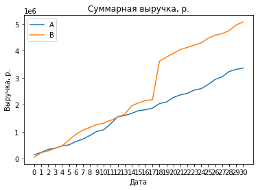

```python
# датафрейм с кумулятивным количеством заказов и кумулятивной выручкой по дням в группе A
cumulativeRevenueA = cumulativeData[cumulativeData['group']=='A'][['date','revenue', 'orders']]

# датафрейм с кумулятивным количеством заказов и кумулятивной выручкой по дням в группе B
cumulativeRevenueB = cumulativeData[cumulativeData['group']=='B'][['date','revenue', 'orders']]

# Строим график выручки группы А
x = list(range(len(cumulativeRevenueA['date'])))
xi = cumulativeRevenueA['date']
plt.xticks(xi, x)
plt.xlabel('Дата')
plt.ylabel('Выручка, р.')
plt.title('Суммарная выручка, р.')

plt.plot(cumulativeRevenueA['date'], cumulativeRevenueA['revenue'], label='A')

# Строим график выручки группы B
plt.plot(cumulativeRevenueB['date'], cumulativeRevenueB['revenue'], label='B')

plt.legend()

plt.show()
```

Группа `A` показывает равномерный рост.  
В группе `B` заметен резкий скачок выручке в середине месяца. Вероятно, был сделан крупный заказ.

#### График кумулятивного среднего чека

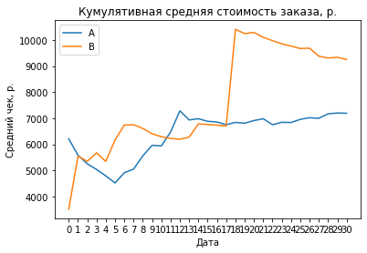

```python
x = list(range(len(cumulativeRevenueA['date'])))
xi = cumulativeRevenueA['date']
plt.xticks(xi, x)
plt.xlabel('Дата')
plt.ylabel('Средний чек, р.')
plt.title('Кумулятивная средняя стоимость заказа, р.')

plt.plot(cumulativeRevenueA['date'], cumulativeRevenueA['revenue']/cumulativeRevenueA['orders'], label='A')
plt.plot(cumulativeRevenueB['date'], cumulativeRevenueB['revenue']/cumulativeRevenueB['orders'], label='B')
plt.legend()
plt.show()
```

Средний чек группы `A` стабилизировался на отметке около 7000р.  
Резкое увеличение среднего чека группы `B` также свидетельствует о наличии крупного заказа в середине месяца.  
В связи с этим средний чек группы `B` еще неизвестен. Вероятнее всего, его значение находится в диапазоне 7000 - 9000 р.

#### График относительного изменения кумулятивного среднего чека

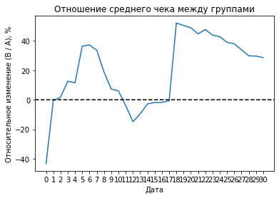

```python
x = list(range(len(cumulativeRevenueA['date'])))
xi = cumulativeRevenueA['date']

plt.xticks(xi, x)
plt.xlabel('Дата')
plt.ylabel('Относительное изменение (B / A), %')
plt.title('Отношение среднего чека между группами')


# собираем данные в одном датафрейме
mergedCumulativeRevenue = cumulativeRevenueA.merge(cumulativeRevenueB,
                                                   left_on='date',
                                                   right_on='date',
                                                   how='left',
                                                   suffixes=['A', 'B'])

# cтроим отношение средних чеков
plt.plot(mergedCumulativeRevenue['date'],
         ((mergedCumulativeRevenue['revenueB']/mergedCumulativeRevenue['ordersB'])/\
         (mergedCumulativeRevenue['revenueA']/mergedCumulativeRevenue['ordersA'])-1)*100)

# добавляем ось X
plt.axhline(y=0, color='black', linestyle='--')

plt.show()
```

Относительное изменение среднего чека группы `B` к `A` также не стабилизировано из-за наличия выбросов.

### Анализ конверсии

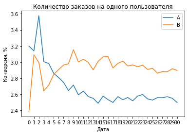

```python
x = list(range(len(cumulativeRevenueA['date'])))
xi = cumulativeRevenueA['date']

plt.xticks(xi, x)
plt.xlabel('Дата')
plt.ylabel('Конверсия, %')
plt.title('Количество заказов на одного пользователя')

# считаем кумулятивную конверсию
cumulativeData['conversion'] = cumulativeData['orders']/cumulativeData['visitors']*100

# отделяем данные по группе A
cumulativeDataA = cumulativeData[cumulativeData['group']=='A']

# отделяем данные по группе B
cumulativeDataB = cumulativeData[cumulativeData['group']=='B']

# строим графики
plt.plot(cumulativeDataA['date'], cumulativeDataA['conversion'], label='A')
plt.plot(cumulativeDataB['date'], cumulativeDataB['conversion'], label='B')
plt.legend()

plt.show()
```

Конверсия обеих групп стабилизировалась. Для группы `B` значения заметно выше.

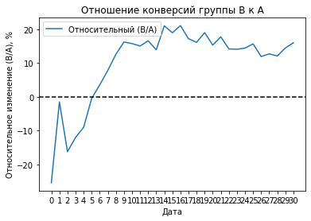

```python
x = list(range(len(cumulativeRevenueA['date'])))
xi = cumulativeRevenueA['date']

plt.xticks(xi, x)
plt.xlabel('Дата')
plt.ylabel('Относительное изменение (B/A), %')
plt.title('Отношение конверсий группы B к A')

mergedCumulativeConversions = cumulativeDataA[['date','conversion']].merge(
    cumulativeDataB[['date','conversion']],
    left_on='date', right_on='date',
    how='left',
    suffixes=['A', 'B']
)

plt.plot(mergedCumulativeConversions['date'],
         (mergedCumulativeConversions['conversionB']/mergedCumulativeConversions['conversionA']-1)*100,
         label="Относительный (B/A)")
plt.legend()

plt.axhline(y=0, color='black', linestyle='--')

plt.show()
```

Конверсия группы `B` на 10-15% выше.

### Анализ аномальных значений

#### Количество заказов одного пользователя

```python
ordersByUsers = (
    orders.groupby('visitorId', as_index=False)
    .agg({'transactionId': 'nunique'})
)

ordersByUsers.columns = ['userId', 'orders']
```

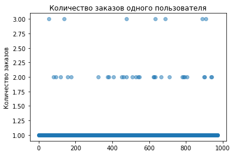

```python
plt.xlabel('')
plt.ylabel('Количество заказов')
plt.title('Количество заказов одного пользователя')

x_values = pd.Series(range(0,len(ordersByUsers)))

plt.scatter(x_values, ordersByUsers['orders'], alpha=0.5)

plt.show()
```

Большинство пользователей совершили 1 заказ.

```python
print(np.percentile(ordersByUsers['orders'], [90, 95, 99]))
```

```
[1. 1. 2.]
```

Менее 5% пользователей более одного заказа.  
Эти данные можно считать выбросами.

#### Выручка одного заказа

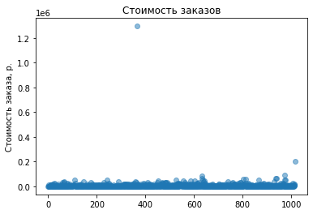

```python
plt.xlabel('')
plt.ylabel('Стоимость заказа, р.')
plt.title('Стоимость заказов')

x_values = pd.Series(range(0,len(orders['revenue'])))
plt.scatter(x_values, orders['revenue'], alpha=0.5)
plt.show()
```

```python
print(np.percentile(orders['revenue'], [90, 95, 99]))
```

```
[17990. 26785. 53904.]
```

Менее 5% заказов были на сумму более 27000 р.  
Эти данные можно считать выбросами.